# Assignment 1: Exploring Neural Networks with IMDB Reviews

### Advanced Machine Learning

In this assignment, I explore how different neural network settings change the way a model learns from IMDB movie reviews. I will compare different model structures and settings instead of depending on a single configuration. My goal is to see which changes improve validation performance and which ones do not make a meaningful difference.

**#ReviewSignalsNN**

```python
# Tools needed for this neural network experiment

import numpy as np
import pandas as pd
import matplotlib.pyplot as plt

from tensorflow import keras
from tensorflow.keras import layers
from tensorflow.keras.datasets import imdb

# Keep my experiment results consistent when the notebook is run again
np.random.seed(27)
keras.utils.set_random_seed(27)
```

```python
# Load IMDB movie reviews
# We will keep the 10,000 most frequently used words

word_limit = 10000

(review_train, label_train), (review_test, label_test) = imdb.load_data(
    num_words=word_limit
)

# Check how much data we received
print("Training reviews:", len(review_train))
print("Testing reviews:", len(review_test))
print("First review label:", label_train[0])
```

```
Training reviews: 25000
Testing reviews: 25000
First review label: 1
```

```python
# Convert each movie review into a binary vector

def encode_movie_reviews(review_collection, vocabulary_size=10000):
    encoded_reviews = np.zeros((len(review_collection), vocabulary_size))

    for review_number, word_numbers in enumerate(review_collection):
        encoded_reviews[review_number, word_numbers] = 1.0

    return encoded_reviews


# Encode both training and testing reviews
train_features = encode_movie_reviews(review_train, word_limit)
test_features = encode_movie_reviews(review_test, word_limit)

# Convert labels into decimal values for the neural network
train_targets = np.asarray(label_train).astype("float32")
test_targets = np.asarray(label_test).astype("float32")

print("Training data shape:", train_features.shape)
print("Testing data shape:", test_features.shape)
```

```
Training data shape: (25000, 10000)
Testing data shape: (25000, 10000)
```

```python
# Separate part of the training data for validation

validation_features = train_features[:10000]
validation_targets = train_targets[:10000]

learning_features = train_features[10000:]
learning_targets = train_targets[10000:]

print("Reviews used for model learning:", learning_features.shape[0])
print("Reviews used for validation:", validation_features.shape[0])
```

```
Reviews used for model learning: 15000
Reviews used for validation: 10000
```

## Experiment 1: One Hidden Layer

I started by testing a simpler neural network with only one hidden layer. I wanted to see whether reducing the depth of the network would still allow it to recognize the difference between positive and negative movie reviews. This also gives me a starting point that I can compare with deeper models later.

```python
# Experiment 1: Neural network with one hidden layer

one_layer_net = keras.Sequential([
    layers.Input(shape=(10000,)),
    layers.Dense(16, activation="relu"),
    layers.Dense(1, activation="sigmoid")
])

one_layer_net.compile(
    optimizer="rmsprop",
    loss="binary_crossentropy",
    metrics=["accuracy"]
)

one_layer_history = one_layer_net.fit(
    learning_features,
    learning_targets,
    epochs=10,
    batch_size=512,
    validation_data=(validation_features, validation_targets),
    verbose=1
)
```

```
30/30 ━━━━━━━━━━━━━━━━━━━━ 9s 199ms/step - accuracy: 0.7881 - loss: 0.5042 - val_accuracy: 0.8460 - val_loss: 0.4122
30/30 ━━━━━━━━━━━━━━━━━━━━ 5s 48ms/step - accuracy: 0.8940 - loss: 0.3290 - val_accuracy: 0.8697 - val_loss: 0.3408
30/30 ━━━━━━━━━━━━━━━━━━━━ 3s 70ms/step - accuracy: 0.9153 - loss: 0.2605 - val_accuracy: 0.8760 - val_loss: 0.3120
30/30 ━━━━━━━━━━━━━━━━━━━━ 1s 47ms/step - accuracy: 0.9287 - loss: 0.2193 - val_accuracy: 0.8798 - val_loss: 0.3000
30/30 ━━━━━━━━━━━━━━━━━━━━ 1s 44ms/step - accuracy: 0.9398 - loss: 0.1907 - val_accuracy: 0.8807 - val_loss: 0.2950
30/30 ━━━━━━━━━━━━━━━━━━━━ 3s 44ms/step - accuracy: 0.9482 - loss: 0.1689 - val_accuracy: 0.8808 - val_loss: 0.2933
30/30 ━━━━━━━━━━━━━━━━━━━━ 1s 46ms/step - accuracy: 0.9543 - loss: 0.1516 - val_accuracy: 0.8818 - val_loss: 0.2949
30/30 ━━━━━━━━━━━━━━━━━━━━ 2s 50ms/step - accuracy: 0.9599 - loss: 0.1369 - val_accuracy: 0.8802 - val_loss: 0.2971
30/30 ━━━━━━━━━━━━━━━━━━━━ 1s 46ms/step - accuracy: 0.9650 - loss: 0.1247 - val_accuracy: 0.8792 - val_loss: 0.3027
30/30 ━━━━━━━━━━━━━━━━━━━━ 3s 64ms/step - accuracy: 0.9688 - loss: 0.1134 - val_accuracy: 0.8785 - val_loss: 0.3054
```

```python
# Save the best validation result from Experiment 1

one_layer_best = max(one_layer_history.history["val_accuracy"])
one_layer_epoch = np.argmax(one_layer_history.history["val_accuracy"]) + 1

print("Best validation accuracy:", round(one_layer_best, 4))
print("Best epoch:", one_layer_epoch)
```

```
Best validation accuracy: 0.8818
Best epoch: 7
```

### Observation

The one-hidden-layer model improved steadily during the first several epochs. An interesting pattern appeared later in training: the training accuracy continued to rise, while the validation accuracy stopped improving and began to decrease slightly. This suggests that simply allowing the model to train longer does not necessarily make it better on unseen reviews. For this model, the strongest validation performance occurred before the final epoch.

## Experiment 2: Three Hidden Layers

Next, I increased the depth of the network from one hidden layer to three hidden layers. I wanted to test whether giving the model more layers would help it capture additional patterns in the reviews, or whether the extra complexity would lead to overfitting.

```python
# Experiment 2: Neural network with three hidden layers

three_layer_net = keras.Sequential([
    layers.Input(shape=(10000,)),
    layers.Dense(16, activation="relu"),
    layers.Dense(16, activation="relu"),
    layers.Dense(16, activation="relu"),
    layers.Dense(1, activation="sigmoid")
])

three_layer_net.compile(
    optimizer="rmsprop",
    loss="binary_crossentropy",
    metrics=["accuracy"]
)

three_layer_history = three_layer_net.fit(
    learning_features,
    learning_targets,
    epochs=10,
    batch_size=512,
    validation_data=(validation_features, validation_targets),
    verbose=1
)
```

```
30/30 ━━━━━━━━━━━━━━━━━━━━ 5s 122ms/step - accuracy: 0.7739 - loss: 0.5464 - val_accuracy: 0.8311 - val_loss: 0.4306
30/30 ━━━━━━━━━━━━━━━━━━━━ 3s 42ms/step - accuracy: 0.8873 - loss: 0.3239 - val_accuracy: 0.8829 - val_loss: 0.3064
30/30 ━━━━━━━━━━━━━━━━━━━━ 2s 58ms/step - accuracy: 0.9170 - loss: 0.2323 - val_accuracy: 0.8845 - val_loss: 0.2870
30/30 ━━━━━━━━━━━━━━━━━━━━ 2s 65ms/step - accuracy: 0.9333 - loss: 0.1859 - val_accuracy: 0.8692 - val_loss: 0.3261
30/30 ━━━━━━━━━━━━━━━━━━━━ 1s 46ms/step - accuracy: 0.9531 - loss: 0.1472 - val_accuracy: 0.8829 - val_loss: 0.2904
30/30 ━━━━━━━━━━━━━━━━━━━━ 2s 39ms/step - accuracy: 0.9543 - loss: 0.1303 - val_accuracy: 0.8811 - val_loss: 0.3029
30/30 ━━━━━━━━━━━━━━━━━━━━ 2s 47ms/step - accuracy: 0.9641 - loss: 0.1105 - val_accuracy: 0.8779 - val_loss: 0.3260
30/30 ━━━━━━━━━━━━━━━━━━━━ 2s 39ms/step - accuracy: 0.9690 - loss: 0.0938 - val_accuracy: 0.8790 - val_loss: 0.3355
30/30 ━━━━━━━━━━━━━━━━━━━━ 2s 54ms/step - accuracy: 0.9780 - loss: 0.0748 - val_accuracy: 0.8761 - val_loss: 0.3617
30/30 ━━━━━━━━━━━━━━━━━━━━ 3s 66ms/step - accuracy: 0.9837 - loss: 0.0604 - val_accuracy: 0.8709 - val_loss: 0.3984
```

```python
one_layer_test_loss, one_layer_test_accuracy = one_layer_net.evaluate(
    test_features, test_targets, verbose=0
)

three_layer_test_loss, three_layer_test_accuracy = three_layer_net.evaluate(
    test_features, test_targets, verbose=0
)

print("1 Hidden Layer Test Accuracy:",
      round(one_layer_test_accuracy * 100, 2), "%")

print("3 Hidden Layers Test Accuracy:",
      round(three_layer_test_accuracy * 100, 2), "%")
```

```
1 Hidden Layer Test Accuracy: 87.14 %
3 Hidden Layers Test Accuracy: 86.18 %
```

```python
# Save the best validation result from Experiment 2

three_layer_best = max(three_layer_history.history["val_accuracy"])
three_layer_epoch = np.argmax(three_layer_history.history["val_accuracy"]) + 1

print("Best validation accuracy:", round(three_layer_best, 4))
print("Best epoch:", three_layer_epoch)
```

```
Best validation accuracy: 0.8845
Best epoch: 3
```

### Observation

Adding more hidden layers gave me a small improvement in the best validation accuracy. The one-hidden-layer model reached 88.18% validation accuracy, while the three-hidden-layer model reached 88.45%. However, the test results showed a different pattern. The one-hidden-layer model achieved 87.14% test accuracy, compared with 86.18% for the three-hidden-layer model. This showed me that adding more layers did not necessarily help the model perform better on unseen reviews. I also noticed that the training accuracy continued to increase while the validation accuracy started to decrease, which suggests that the deeper model was beginning to overfit.

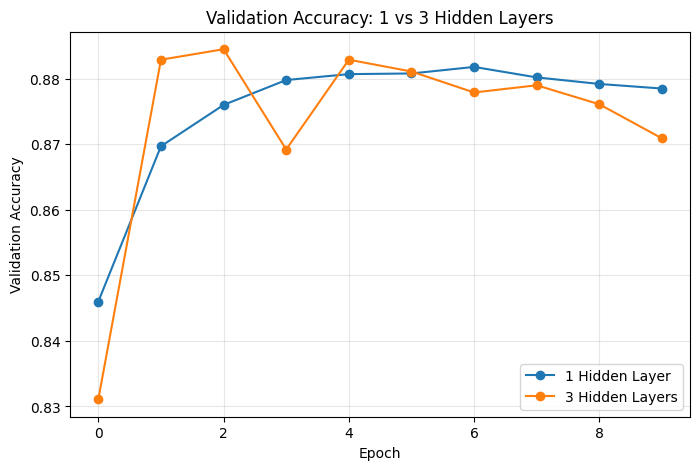

```python
plt.figure(figsize=(8, 5))

plt.plot(one_layer_history.history["val_accuracy"],
         marker="o",
         label="1 Hidden Layer")

plt.plot(three_layer_history.history["val_accuracy"],
         marker="o",
         label="3 Hidden Layers")

plt.xlabel("Epoch")
plt.ylabel("Validation Accuracy")
plt.title("Validation Accuracy: 1 vs 3 Hidden Layers")
plt.legend()
plt.grid(alpha=0.3)
plt.show()
```

## Experiment 3: Increasing the Hidden Units

For this experiment, I changed the number of units inside the hidden layers. I wanted to see whether giving the network more capacity would help it identify useful patterns in the movie reviews. I started with 32 units and will compare the result with a larger 64-unit version.

```python
# Experiment 3A: Two hidden layers with 32 units each

units_32_net = keras.Sequential([
    layers.Input(shape=(10000,)),
    layers.Dense(32, activation="relu"),
    layers.Dense(32, activation="relu"),
    layers.Dense(1, activation="sigmoid")
])

units_32_net.compile(
    optimizer="rmsprop",
    loss="binary_crossentropy",
    metrics=["accuracy"]
)

units_32_history = units_32_net.fit(
    learning_features,
    learning_targets,
    epochs=10,
    batch_size=512,
    validation_data=(validation_features, validation_targets),
    verbose=1
)
```

```
30/30 ━━━━━━━━━━━━━━━━━━━━ 4s 95ms/step - accuracy: 0.7626 - loss: 0.5250 - val_accuracy: 0.8389 - val_loss: 0.4081
30/30 ━━━━━━━━━━━━━━━━━━━━ 2s 60ms/step - accuracy: 0.8937 - loss: 0.3132 - val_accuracy: 0.8861 - val_loss: 0.3011
30/30 ━━━━━━━━━━━━━━━━━━━━ 2s 52ms/step - accuracy: 0.9179 - loss: 0.2363 - val_accuracy: 0.8554 - val_loss: 0.3530
30/30 ━━━━━━━━━━━━━━━━━━━━ 2s 59ms/step - accuracy: 0.9297 - loss: 0.1951 - val_accuracy: 0.8837 - val_loss: 0.2874
30/30 ━━━━━━━━━━━━━━━━━━━━ 2s 60ms/step - accuracy: 0.9443 - loss: 0.1628 - val_accuracy: 0.8774 - val_loss: 0.3122
30/30 ━━━━━━━━━━━━━━━━━━━━ 3s 72ms/step - accuracy: 0.9536 - loss: 0.1367 - val_accuracy: 0.8841 - val_loss: 0.2945
30/30 ━━━━━━━━━━━━━━━━━━━━ 2s 53ms/step - accuracy: 0.9608 - loss: 0.1169 - val_accuracy: 0.8822 - val_loss: 0.3102
30/30 ━━━━━━━━━━━━━━━━━━━━ 2s 54ms/step - accuracy: 0.9637 - loss: 0.1085 - val_accuracy: 0.8771 - val_loss: 0.3340
30/30 ━━━━━━━━━━━━━━━━━━━━ 3s 53ms/step - accuracy: 0.9747 - loss: 0.0821 - val_accuracy: 0.8745 - val_loss: 0.3552
30/30 ━━━━━━━━━━━━━━━━━━━━ 2s 55ms/step - accuracy: 0.9773 - loss: 0.0763 - val_accuracy: 0.8693 - val_loss: 0.3878
```

```python
# Record the strongest result from the 32-unit model

units_32_best = max(units_32_history.history["val_accuracy"])
units_32_epoch = np.argmax(units_32_history.history["val_accuracy"]) + 1

print("Best validation accuracy:", round(units_32_best, 4))
print("Best epoch:", units_32_epoch)
```

```
Best validation accuracy: 0.8861
Best epoch: 2
```

```python
# Experiment 3B: Two hidden layers with 64 units each

units_64_net = keras.Sequential([
    layers.Input(shape=(10000,)),
    layers.Dense(64, activation="relu"),
    layers.Dense(64, activation="relu"),
    layers.Dense(1, activation="sigmoid")
])

units_64_net.compile(
    optimizer="rmsprop",
    loss="binary_crossentropy",
    metrics=["accuracy"]
)

units_64_history = units_64_net.fit(
    learning_features,
    learning_targets,
    epochs=10,
    batch_size=512,
    validation_data=(validation_features, validation_targets),
    verbose=1
)
```

```
30/30 ━━━━━━━━━━━━━━━━━━━━ 5s 129ms/step - accuracy: 0.7467 - loss: 0.5200 - val_accuracy: 0.8511 - val_loss: 0.3832
30/30 ━━━━━━━━━━━━━━━━━━━━ 2s 70ms/step - accuracy: 0.8844 - loss: 0.3055 - val_accuracy: 0.8869 - val_loss: 0.2882
30/30 ━━━━━━━━━━━━━━━━━━━━ 2s 71ms/step - accuracy: 0.9079 - loss: 0.2372 - val_accuracy: 0.8843 - val_loss: 0.2869
30/30 ━━━━━━━━━━━━━━━━━━━━ 2s 67ms/step - accuracy: 0.9282 - loss: 0.1915 - val_accuracy: 0.8671 - val_loss: 0.3328
30/30 ━━━━━━━━━━━━━━━━━━━━ 3s 97ms/step - accuracy: 0.9469 - loss: 0.1513 - val_accuracy: 0.8871 - val_loss: 0.2858
30/30 ━━━━━━━━━━━━━━━━━━━━ 3s 84ms/step - accuracy: 0.9505 - loss: 0.1352 - val_accuracy: 0.8810 - val_loss: 0.3107
30/30 ━━━━━━━━━━━━━━━━━━━━ 2s 74ms/step - accuracy: 0.9601 - loss: 0.1133 - val_accuracy: 0.8813 - val_loss: 0.3138
30/30 ━━━━━━━━━━━━━━━━━━━━ 2s 71ms/step - accuracy: 0.9639 - loss: 0.0967 - val_accuracy: 0.8801 - val_loss: 0.3318
30/30 ━━━━━━━━━━━━━━━━━━━━ 2s 73ms/step - accuracy: 0.9797 - loss: 0.0666 - val_accuracy: 0.8744 - val_loss: 0.3732
30/30 ━━━━━━━━━━━━━━━━━━━━ 2s 82ms/step - accuracy: 0.9803 - loss: 0.0613 - val_accuracy: 0.8776 - val_loss: 0.3812
```

```python
# Record the strongest result from the 64-unit model

units_64_best = max(units_64_history.history["val_accuracy"])
units_64_epoch = np.argmax(units_64_history.history["val_accuracy"]) + 1

print("Best validation accuracy:", round(units_64_best, 4))
print("Best epoch:", units_64_epoch)
```

```
Best validation accuracy: 0.8871
Best epoch: 5
```

### Observation

Increasing the number of hidden units produced a small change in validation performance. The 64-unit model reached a slightly higher peak validation accuracy than the 32-unit model, but the difference was very small. I also noticed that both models reached their strongest validation results early in training, while their training accuracy continued to increase afterward. This suggests that adding more units gave the network more capacity, but the extra capacity did not create a large improvement on unseen reviews.

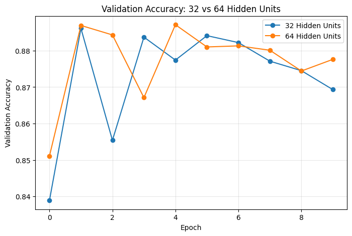

```python
plt.figure(figsize=(8, 5))

plt.plot(units_32_history.history["val_accuracy"],
         marker="o",
         label="32 Hidden Units")

plt.plot(units_64_history.history["val_accuracy"],
         marker="o",
         label="64 Hidden Units")

plt.xlabel("Epoch")
plt.ylabel("Validation Accuracy")
plt.title("Validation Accuracy: 32 vs 64 Hidden Units")
plt.legend()
plt.grid(alpha=0.3)
plt.show()
```

## Experiment 4: Using MSE as the Loss Function

So far, my models have used binary crossentropy as the loss function. For this experiment, I changed the loss function to mean squared error (MSE) while keeping the basic network structure consistent. I wanted to see how changing only the way prediction errors are measured would affect the model's validation performance.

```python
# Experiment 4: Using mean squared error as the loss function

mse_net = keras.Sequential([
    layers.Input(shape=(10000,)),
    layers.Dense(16, activation="relu"),
    layers.Dense(16, activation="relu"),
    layers.Dense(1, activation="sigmoid")
])

mse_net.compile(
    optimizer="rmsprop",
    loss="mse",
    metrics=["accuracy"]
)

mse_history = mse_net.fit(
    learning_features,
    learning_targets,
    epochs=10,
    batch_size=512,
    validation_data=(validation_features, validation_targets),
    verbose=1
)
```

```
30/30 ━━━━━━━━━━━━━━━━━━━━ 4s 92ms/step - accuracy: 0.7640 - loss: 0.1821 - val_accuracy: 0.8344 - val_loss: 0.1374
30/30 ━━━━━━━━━━━━━━━━━━━━ 1s 40ms/step - accuracy: 0.8863 - loss: 0.1042 - val_accuracy: 0.8844 - val_loss: 0.0991
30/30 ━━━━━━━━━━━━━━━━━━━━ 1s 41ms/step - accuracy: 0.9138 - loss: 0.0774 - val_accuracy: 0.8871 - val_loss: 0.0902
30/30 ━━━━━━━━━━━━━━━━━━━━ 2s 51ms/step - accuracy: 0.9262 - loss: 0.0642 - val_accuracy: 0.8801 - val_loss: 0.0912
30/30 ━━━━━━━━━━━━━━━━━━━━ 1s 42ms/step - accuracy: 0.9425 - loss: 0.0531 - val_accuracy: 0.8677 - val_loss: 0.0962
30/30 ━━━━━━━━━━━━━━━━━━━━ 2s 52ms/step - accuracy: 0.9513 - loss: 0.0461 - val_accuracy: 0.8860 - val_loss: 0.0846
30/30 ━━━━━━━━━━━━━━━━━━━━ 2s 67ms/step - accuracy: 0.9555 - loss: 0.0413 - val_accuracy: 0.8810 - val_loss: 0.0877
30/30 ━━━━━━━━━━━━━━━━━━━━ 2s 57ms/step - accuracy: 0.9645 - loss: 0.0359 - val_accuracy: 0.8831 - val_loss: 0.0856
30/30 ━━━━━━━━━━━━━━━━━━━━ 2s 51ms/step - accuracy: 0.9666 - loss: 0.0327 - val_accuracy: 0.8829 - val_loss: 0.0864
30/30 ━━━━━━━━━━━━━━━━━━━━ 2s 54ms/step - accuracy: 0.9749 - loss: 0.0285 - val_accuracy: 0.8723 - val_loss: 0.0944
```

```python
# Record the strongest validation result from the MSE model

mse_best = max(mse_history.history["val_accuracy"])
mse_best_epoch = np.argmax(mse_history.history["val_accuracy"]) + 1

print("Best validation accuracy:", round(mse_best, 4))
print("Best epoch:", mse_best_epoch)
```

```
Best validation accuracy: 0.8871
Best epoch: 3
```

### Observation

Changing the loss function to MSE still produced competitive validation accuracy. The model improved quickly during the early epochs, but the validation performance did not continue improving as the training accuracy increased. This helped me see that changing the loss function affects the learning process, but a lower training error does not necessarily translate into better performance on unseen reviews.

## Experiment 5: Changing the Activation Function to Tanh

In the previous models, I used ReLU in the hidden layers. For this experiment, I replaced ReLU with tanh while keeping the rest of the model fairly simple. I wanted to see whether changing the way the hidden layers transform information would make a noticeable difference in validation performance.

```python
# Experiment 5: Using tanh instead of ReLU

tanh_net = keras.Sequential([
    layers.Input(shape=(10000,)),
    layers.Dense(16, activation="tanh"),
    layers.Dense(16, activation="tanh"),
    layers.Dense(1, activation="sigmoid")
])

tanh_net.compile(
    optimizer="rmsprop",
    loss="binary_crossentropy",
    metrics=["accuracy"]
)

tanh_history = tanh_net.fit(
    learning_features,
    learning_targets,
    epochs=10,
    batch_size=512,
    validation_data=(validation_features, validation_targets),
    verbose=1
)
```

```
30/30 ━━━━━━━━━━━━━━━━━━━━ 4s 92ms/step - accuracy: 0.7889 - loss: 0.4928 - val_accuracy: 0.8608 - val_loss: 0.3740
30/30 ━━━━━━━━━━━━━━━━━━━━ 2s 59ms/step - accuracy: 0.8996 - loss: 0.2923 - val_accuracy: 0.8782 - val_loss: 0.3067
30/30 ━━━━━━━━━━━━━━━━━━━━ 3s 60ms/step - accuracy: 0.9252 - loss: 0.2138 - val_accuracy: 0.8828 - val_loss: 0.2829
30/30 ━━━━━━━━━━━━━━━━━━━━ 2s 53ms/step - accuracy: 0.9401 - loss: 0.1722 - val_accuracy: 0.8790 - val_loss: 0.2992
30/30 ━━━━━━━━━━━━━━━━━━━━ 2s 54ms/step - accuracy: 0.9522 - loss: 0.1378 - val_accuracy: 0.8625 - val_loss: 0.3593
30/30 ━━━━━━━━━━━━━━━━━━━━ 2s 54ms/step - accuracy: 0.9603 - loss: 0.1149 - val_accuracy: 0.8823 - val_loss: 0.3147
30/30 ━━━━━━━━━━━━━━━━━━━━ 2s 48ms/step - accuracy: 0.9675 - loss: 0.0923 - val_accuracy: 0.8774 - val_loss: 0.3463
30/30 ━━━━━━━━━━━━━━━━━━━━ 1s 45ms/step - accuracy: 0.9733 - loss: 0.0795 - val_accuracy: 0.8696 - val_loss: 0.3935
30/30 ━━━━━━━━━━━━━━━━━━━━ 3s 66ms/step - accuracy: 0.9805 - loss: 0.0623 - val_accuracy: 0.8431 - val_loss: 0.5375
30/30 ━━━━━━━━━━━━━━━━━━━━ 2s 45ms/step - accuracy: 0.9847 - loss: 0.0525 - val_accuracy: 0.8713 - val_loss: 0.4467
```

```python
# Record the strongest validation result from the tanh model

tanh_best = max(tanh_history.history["val_accuracy"])
tanh_best_epoch = np.argmax(tanh_history.history["val_accuracy"]) + 1

print("Best validation accuracy:", round(tanh_best, 4))
print("Best epoch:", tanh_best_epoch)
```

```
Best validation accuracy: 0.8828
Best epoch: 3
```

### Observation

The tanh model performed reasonably well, but its best validation accuracy was lower than some of the ReLU-based models I tested earlier. I also noticed that the training accuracy continued to increase while validation performance became less consistent in the later epochs. In my experiment, switching from ReLU to tanh did not provide an improvement, which shows that changing the activation function can influence how well the model generalizes.

## Experiment 6: Reducing Overfitting with Dropout

In several of my earlier experiments, the training accuracy continued to improve even after the validation accuracy stopped improving. For this experiment, I added dropout to see whether reducing the network's dependence on particular hidden units could help control overfitting and produce more stable validation performance.

```python
# Experiment 6: Add dropout to reduce overfitting

dropout_net = keras.Sequential([
    layers.Input(shape=(10000,)),
    layers.Dense(32, activation="relu"),
    layers.Dropout(0.4),
    layers.Dense(32, activation="relu"),
    layers.Dropout(0.4),
    layers.Dense(1, activation="sigmoid")
])

dropout_net.compile(
    optimizer="rmsprop",
    loss="binary_crossentropy",
    metrics=["accuracy"]
)

dropout_history = dropout_net.fit(
    learning_features,
    learning_targets,
    epochs=10,
    batch_size=512,
    validation_data=(validation_features, validation_targets),
    verbose=1
)
```

```
30/30 ━━━━━━━━━━━━━━━━━━━━ 3s 85ms/step - accuracy: 0.6917 - loss: 0.5906 - val_accuracy: 0.8223 - val_loss: 0.4505
30/30 ━━━━━━━━━━━━━━━━━━━━ 2s 61ms/step - accuracy: 0.8455 - loss: 0.4018 - val_accuracy: 0.8792 - val_loss: 0.3203
30/30 ━━━━━━━━━━━━━━━━━━━━ 2s 73ms/step - accuracy: 0.8898 - loss: 0.3029 - val_accuracy: 0.8870 - val_loss: 0.2817
30/30 ━━━━━━━━━━━━━━━━━━━━ 2s 73ms/step - accuracy: 0.9140 - loss: 0.2404 - val_accuracy: 0.8810 - val_loss: 0.3018
30/30 ━━━━━━━━━━━━━━━━━━━━ 2s 53ms/step - accuracy: 0.9298 - loss: 0.2040 - val_accuracy: 0.8845 - val_loss: 0.2903
30/30 ━━━━━━━━━━━━━━━━━━━━ 2s 59ms/step - accuracy: 0.9419 - loss: 0.1672 - val_accuracy: 0.8819 - val_loss: 0.3141
30/30 ━━━━━━━━━━━━━━━━━━━━ 2s 52ms/step - accuracy: 0.9533 - loss: 0.1400 - val_accuracy: 0.8833 - val_loss: 0.3208
30/30 ━━━━━━━━━━━━━━━━━━━━ 3s 53ms/step - accuracy: 0.9623 - loss: 0.1158 - val_accuracy: 0.8815 - val_loss: 0.3437
30/30 ━━━━━━━━━━━━━━━━━━━━ 2s 52ms/step - accuracy: 0.9650 - loss: 0.1023 - val_accuracy: 0.8868 - val_loss: 0.3426
30/30 ━━━━━━━━━━━━━━━━━━━━ 2s 79ms/step - accuracy: 0.9753 - loss: 0.0797 - val_accuracy: 0.8740 - val_loss: 0.4177
```

```python
# Record the strongest validation result from the dropout model

dropout_best = max(dropout_history.history["val_accuracy"])
dropout_best_epoch = np.argmax(dropout_history.history["val_accuracy"]) + 1

print("Best validation accuracy:", round(dropout_best, 4))
print("Best epoch:", dropout_best_epoch)
```

```
Best validation accuracy: 0.887
Best epoch: 3
```

### Observation

The dropout model showed a different learning pattern from some of the earlier models. Its training accuracy increased more gradually, which makes sense because dropout intentionally removes some hidden-unit connections during training. Even with this restriction, the model maintained competitive validation performance. This experiment helped me see that controlling model complexity can be useful when the training accuracy is increasing faster than the validation accuracy.

## Comparing My Neural Network Experiments

After testing different network structures and settings, I brought the results together so I could compare them more clearly. I used the highest validation accuracy reached by each model rather than simply using the accuracy from the final epoch.

```python
# Bring all experiment results together

experiment_summary = pd.DataFrame({
    "Experiment": [
        "1 Hidden Layer",
        "3 Hidden Layers",
        "32 Hidden Units",
        "64 Hidden Units",
        "MSE Loss",
        "Tanh Activation",
        "Dropout"
    ],
    "Best Validation Accuracy": [
        one_layer_best,
        three_layer_best,
        units_32_best,
        units_64_best,
        mse_best,
        tanh_best,
        dropout_best
    ],
    "Best Epoch": [
        one_layer_epoch,
        three_layer_epoch,
        units_32_epoch,
        units_64_epoch,
        mse_best_epoch,
        tanh_best_epoch,
        dropout_best_epoch
    ]
})

# Show accuracy as a percentage for easier comparison
experiment_summary["Validation Accuracy (%)"] = (
    experiment_summary["Best Validation Accuracy"] * 100
).round(2)

experiment_summary[
    ["Experiment", "Validation Accuracy (%)", "Best Epoch"]
]
```

|  | Experiment | Validation Accuracy (%) | Best Epoch |
| --- | --- | --- | --- |
| 0 | 1 Hidden Layer | 88.18 | 7 |
| 1 | 3 Hidden Layers | 88.45 | 3 |
| 2 | 32 Hidden Units | 88.61 | 2 |
| 3 | 64 Hidden Units | 88.71 | 5 |
| 4 | MSE Loss | 88.71 | 3 |
| 5 | Tanh Activation | 88.28 | 3 |
| 6 | Dropout | 88.70 | 3 |

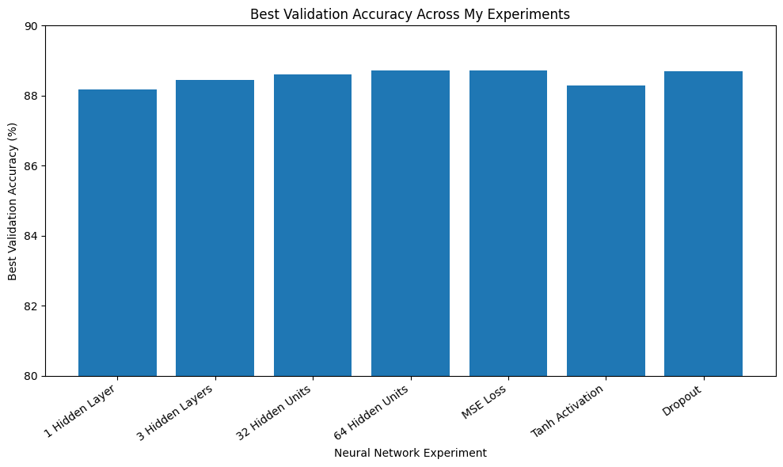

```python
# Visual comparison of the experiments

plt.figure(figsize=(10, 6))

plt.bar(
    experiment_summary["Experiment"],
    experiment_summary["Validation Accuracy (%)"]
)

plt.title("Best Validation Accuracy Across My Experiments")
plt.xlabel("Neural Network Experiment")
plt.ylabel("Best Validation Accuracy (%)")
plt.ylim(80, 90)

plt.xticks(rotation=35, ha="right")
plt.tight_layout()
plt.show()
```

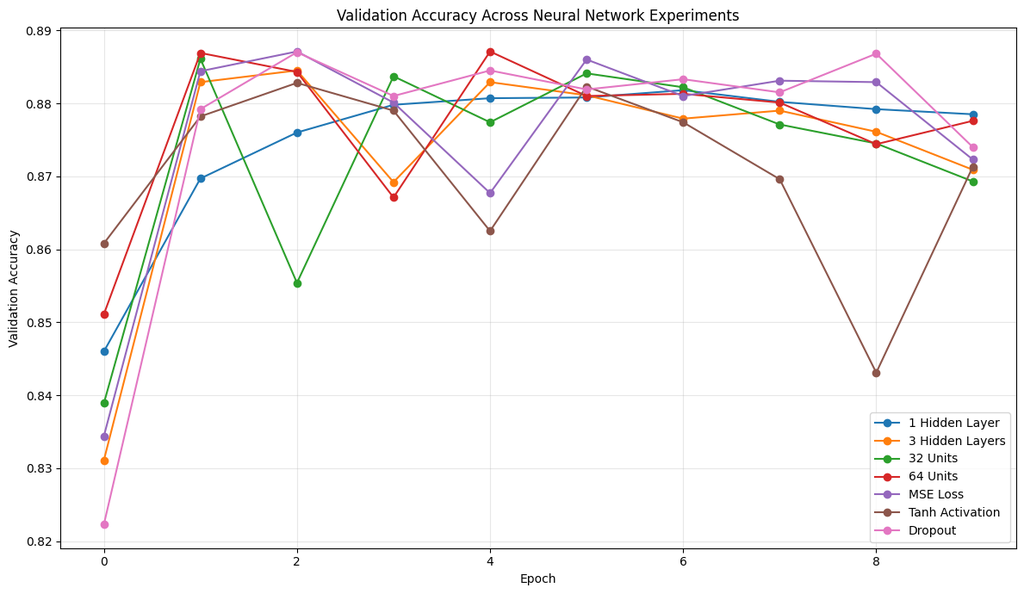

```python
# Compare training and validation accuracy across all experiments

plt.figure(figsize=(12, 7))

experiment_histories = {
    '1 Hidden Layer': one_layer_history,
    '3 Hidden Layers': three_layer_history,
    '32 Units': units_32_history,
    '64 Units': units_64_history,
    'MSE Loss': mse_history,
    'Tanh Activation': tanh_history,
    'Dropout': dropout_history
}

for experiment_name, history in experiment_histories.items():
    plt.plot(
        history.history['val_accuracy'],
        marker='o',
        label=experiment_name
    )

plt.title('Validation Accuracy Across Neural Network Experiments')
plt.xlabel('Epoch')
plt.ylabel('Validation Accuracy')
plt.legend()
plt.grid(True, alpha=0.3)
plt.tight_layout()

plt.show()
```

## Final Model Evaluation

The 64-unit configuration was one of the strongest models in my validation experiments. Its best validation performance occurred at epoch 5, so I trained a fresh version of this architecture for five epochs before evaluating it on the test data .This avoids using the later epochs where validation performance had already started to decline.

```python
# Train a fresh version of the selected architecture

final_review_net = keras.Sequential([
    layers.Input(shape=(10000,)),
    layers.Dense(64, activation="relu"),
    layers.Dense(64, activation="relu"),
    layers.Dense(1, activation="sigmoid")
])

final_review_net.compile(
    optimizer="rmsprop",
    loss="binary_crossentropy",
    metrics=["accuracy"]
)

final_review_net.fit(
    learning_features,
    learning_targets,
    epochs=5,
    batch_size=512,
    verbose=1
)

# Evaluate the final model on the test reviews
final_test_loss, final_test_accuracy = final_review_net.evaluate(
    test_features,
    test_targets,
    verbose=0
)

print("Final test accuracy:", round(final_test_accuracy * 100, 2), "%")
print("Final test loss:", round(final_test_loss, 4))
```

```
30/30 ━━━━━━━━━━━━━━━━━━━━ 2s 51ms/step - accuracy: 0.7525 - loss: 0.5003
30/30 ━━━━━━━━━━━━━━━━━━━━ 3s 50ms/step - accuracy: 0.8818 - loss: 0.3045
30/30 ━━━━━━━━━━━━━━━━━━━━ 3s 49ms/step - accuracy: 0.9109 - loss: 0.2295
30/30 ━━━━━━━━━━━━━━━━━━━━ 3s 79ms/step - accuracy: 0.9305 - loss: 0.1855
30/30 ━━━━━━━━━━━━━━━━━━━━ 2s 63ms/step - accuracy: 0.9486 - loss: 0.1431
Final test accuracy: 87.92 %
Final test loss: 0.3085
```

## Final Conclusion

Working through these experiments showed me that making a neural network larger or more complicated does not automatically make it perform better. My one-hidden-layer model reached 88.18% validation accuracy, while the three-hidden-layer model reached 88.45%. However, the test results showed a different pattern. The one-hidden-layer model achieved 87.14% test accuracy, compared with 86.18% for the three-hidden-layer model. This helped me see that a small improvement in validation accuracy does not always lead to better performance on unseen data.

Increasing the number of hidden units was more useful in my experiments. The 32-unit model reached 88.61% validation accuracy, while the 64-unit model reached 88.71%. Changing other parts of the network also produced similar results. Using MSE gave a best validation accuracy of 88.71%, the tanh model reached 88.28%, and the dropout model reached 88.70%. Since these results were very close, no single change produced a dramatic improvement.

Another pattern I noticed was that training accuracy continued to increase even when validation accuracy stopped improving. This made overfitting easier for me to recognize and showed me why training accuracy alone does not give the full picture of how well a model is performing.

For the final evaluation, I used the 64-unit architecture, which was one of the strongest configurations during validation. The final model achieved 87.92% accuracy on the untouched test data, with a test loss of 0.3085. Overall, these experiments helped me understand that neural network tuning is not simply about adding more layers or units. It is about comparing different settings and finding a balance between learning the training data and performing well on data the model has not seen before.